# Introduction

소개 : 분자생물학 시간에 콜레라 등의 질병이 과거의 수질이 좋지 않았던 것이 원인임을 배웠다. 지금은 오염된 물로 인한 질병은 거의 없다. 한마디로 수질에 영향을 미치는 요인을 분석하여 수질을 개선하였기에 가능한 것 이었을 것이다. 공공데이터포털에서 부산의 해양환경 데이터 셋을 보고 수질을 예측할 수 있을 것이라 생각하여 이를 주제로 선정하였다.

DATA = 부산광역시 해양환경 현황 데이터

A. 수질 평가 지수 (WQI) 예측모델 (다중회귀)

1. EDA
1. Exploratory Data Visualization
1. Model

   3 - 1. 수정된 결정계수 확인

   3 - 2. 회귀계수 확인 후 해석
1. Evaluating the Model's Fit and modifying

```
4 - 1. Type II ANOVA

4 - 2. AIC
```

1. Prediction

B. 수질의 좋음 or 나쁨 예측 ( Logistic )

1. classification
2. Model
3. Prediction
4. Rank by prediction

# Loading packages

```python
import numpy as np
import pandas as pd
import scipy as sp
from scipy import stats

from matplotlib import pyplot as plt
import seaborn as sns
sns.set()

# 선형모델을 추정하는 라이브러리 (경고가 나올 수 있음)
import statsmodels.formula.api as smf
import statsmodels.api as sm

%precision 3
%matplotlib inline



!pip install IPython
from IPython.display import Image
```

```python
import matplotlib.font_manager as fm

# 설치된 폰트 출력
font_list = [font.name for font in fm.fontManager.ttflist]
font_list
plt.rcParams['font.family'] = 'Malgun Gothic'
```

# Loading Dataset

https://www.data.go.kr/data/3077374/fileData.do

```python
water = pd.read_csv("부산광역시_해양환경 현황.csv",encoding = 'cp949')
water.head()
```

|  | 2020년 분기 | 조사정점 | pH | 총대장균군(MPN/100mL) | WQI | 등급 | DIN(점수) | DIN(μg/L) | DIP(점수) | DIP(μg/L) | ... | As( μg/L) | Cd( μg/L) | Ni( μg/L) | COD(mg/L) | T-N(μg/L) | T-P(μg/L) | DO(mg/L) | 수온(℃) | 전기전도도(mS/㎝) | 염분(psu) |
| --- | --- | --- | --- | --- | --- | --- | --- | --- | --- | --- | --- | --- | --- | --- | --- | --- | --- | --- | --- | --- | --- |
| 0 | 1 | 고리 | 7.72 | 23 | 20 | I | 1 | 94.0 | 1 | 6.8 | ... | 0.0 | 0.00 | 0.78 | 1.32 | 203.5 | 7.9 | 8.18 | 14.11 | 50.9 | 33.40 |
| 1 | 1 | 일광 | 8.05 | 2 | 26 | II | 1 | 99.0 | 1 | 18.2 | ... | 0.0 | 0.10 | 0.23 | 0.80 | 255.9 | 23.7 | 8.07 | 13.66 | 50.8 | 33.31 |
| 2 | 1 | 대변 | 8.12 | 2 | 26 | II | 1 | 111.4 | 1 | 10.5 | ... | 0.0 | 0.09 | 0.22 | 0.92 | 234.9 | 17.8 | 8.06 | 13.46 | 50.8 | 33.34 |
| 3 | 1 | 해운대해수욕장 | 8.00 | 330 | 23 | I | 1 | 132.5 | 1 | 14.4 | ... | 0.0 | 0.03 | 0.18 | 0.88 | 259.8 | 18.5 | 8.05 | 13.75 | 50.9 | 33.41 |
| 4 | 1 | 해운대 | 8.02 | 170 | 20 | I | 1 | 184.7 | 1 | 21.8 | ... | 0.0 | 0.05 | 0.43 | 0.92 | 385.7 | 24.8 | 7.99 | 13.72 | 50.5 | 33.10 |

5 rows × 29 columns

```python
water.columns
```

```
Index(['2020년 분기', '조사정점', 'pH', '총대장균군(MPN/100mL)', 'WQI', '등급', 'DIN(점수)',
       'DIN(μg/L)', 'DIP(점수)', 'DIP(μg/L)', 'Chl-a(점수)', 'Chl-a(μg/L)',
       '저층산소포화도(점수)', '저층산소포화도(DO,%)', '투명도(점수)', '투명도(m)', 'Cu( μg/L)',
       'Pb( μg/L)', 'Zn( μg/L)', 'As( μg/L)', 'Cd( μg/L)', 'Ni( μg/L)',
       'COD(mg/L)', 'T-N(μg/L)', 'T-P(μg/L)', 'DO(mg/L)', '수온(℃)',
       '전기전도도(mS/㎝)', '염분(psu)'],
      dtype='object')
```

### columns info

WQI = 수질평가지수

DIN = 용존무기질소

DIP = 용존무기인

Chl- a = 엽록소 a

COD = 화학적산소요구량

T-N = 총 질소

T-P = 총 인

DO = 용존산소

```python
water.info()
```

[output not shown]

[output cut: 19 more lines]

```python
print(water.shape)
```

[output not shown]

```python
water.isnull().sum()
```

[output not shown]

화학 원소에만 결측치가 있는데, 이는 데이터의 1분기, 3분기와 2분기, 4분기에 각각 조사한 해양이 다른데, 2분기, 4분기에는 원소를 측정하지 않았기 때문이다. 그래서 따로 결측치 제거를 해주지 않는다.

# 1 . EDA

```python
print(water.shape)
```

[output not shown]

```python
#1. 필요없는 열은 제거한다. (점수열 제거 )
water = water.drop(['DIN(점수)','DIP(점수)','Chl-a(점수)','저층산소포화도(점수)','투명도(점수)'],axis = 1)
```

```python
water.columns
```

```
Index(['2020년 분기', '조사정점', 'pH', '총대장균군(MPN/100mL)', 'WQI', '등급', 'DIN(μg/L)',
       'DIP(μg/L)', 'Chl-a(μg/L)', '저층산소포화도(DO,%)', '투명도(m)', 'Cu( μg/L)',
       'Pb( μg/L)', 'Zn( μg/L)', 'As( μg/L)', 'Cd( μg/L)', 'Ni( μg/L)',
       'COD(mg/L)', 'T-N(μg/L)', 'T-P(μg/L)', 'DO(mg/L)', '수온(℃)',
       '전기전도도(mS/㎝)', '염분(psu)'],
      dtype='object')
```

```python
#2. column명을 영어로 바꿔준다.
water.columns= ['2020년 분기','조사정점','pH','total coliform group','WQI','rank','DIN','DIP','Chl_a','LDO',
                        'SD','Cu','Pb','Zn','Aa','Cd','Ni','COD','T-N','T-P','DO','temperature',
                         'electrical_conductivity','salt']
```

# 2. Exploratory Data Visualization

```python
sns.pairplot(water,vars = ['조사정점', 'pH', '총대장균군(MPN/100mL)', 'WQI', '등급', 'DIN(μg/L)', 'DIP(μg/L)',
       'Chl-a(μg/L)', '저층산소포화도(DO,%)', '투명도(m)', 'Cu( μg/L)', 'Pb( μg/L)',
       'Zn( μg/L)', 'As( μg/L)', 'Cd( μg/L)', 'Ni( μg/L)', 'COD(mg/L)',
       'T-N(μg/L)', 'T-P(μg/L)', 'DO(mg/L)', '수온(℃)', '전기전도도(mS/㎝)',
       '염분(psu)'])
```

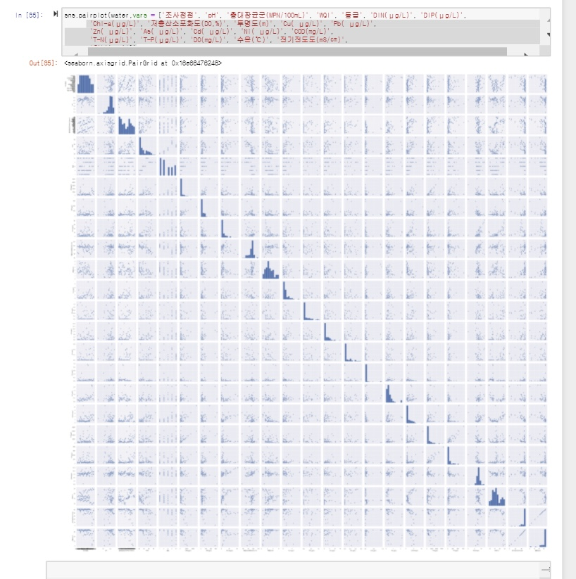

```python
Image('그림1.jpg')
```

pairplot결과 : 표본의 수(100)가 너무 작아서 그런지 그래프만으로 상관관계를 파악하는 것이 어려웠다. 그래서 corr()함수를 사용하여 상관관계를 분석하려고 하였다.

```python
water.corr()['WQI'].sort_values()
```

```
LDO                       -0.732697
salt                      -0.581213
electrical_conductivity   -0.568719
SD                        -0.505370
Cd                        -0.323827
DO                        -0.097738
pH                        -0.095372
Ni                         0.098114
T-P                        0.221800
Pb                         0.309485
T-N                        0.318164
Aa                         0.322514
Cu                         0.399814
Zn                         0.424378
DIN                        0.433748
DIP                        0.470892
Chl_a                      0.562096
temperature                0.576176
COD                        0.652031
WQI                        1.000000
Name: WQI, dtype: float64
```

< WQI와 상관관계가 있는 변수>

1. 0.4이상인 DIN과 DIP는 약간의 상관관계가 있음
2. Chl-a와 수온은 약 0.5정도의 상관관계
3. COD도 0.65 정도의 상관관계 있음
4. 음의 상관관계 = LDO( -0.732697) > salt( -0.581213 ) >electrical_conductivity (-0.568719)
5. 상관관계만 따지면 제일 큰 건 LDO(저층산소포화도)> COD > salt(염분)

=> 저층산소포화도, 염분, 전기전도도 , 투명도 , DIP , Chl-a ,수온 , COD 와 상관관계가 있다.

=> 이들을 독립변수로 이용하여 수질을 예측하는 모델을 만들 수 있다.

# 3. Model

```python
lm_water = smf.ols( "WQI ~ LDO + salt + electrical_conductivity + SD + DIP + Chl_a + temperature + COD ",
                   data=water).fit()
```

### 3 - 1. 수정된 결정계수 확인

다중회귀분석은 단순회귀분석과는 달리 독립변수가 2개이상 들어간다.

독립변수의 수는 그 수가 많을 수록 결정계수 값이 올라가는 특성이 있다.

이를 보완한 것이 수정된 결정계수이다.

수정된 결정계수는 평균제곱오차가 가장 작은 축소모형을 선택한다. 이는 모형의 간결성과 설명력을 동시해 고려한 것이다.

따라서, 다중회귀분석에서 결정계수값을 보고 모형의 설명력을 판단하면 잘못된 판단을 할 수 있기때문에 수정된 결정계수값을 보고 모형의 설명력을 판단해야한다.

```python
lm_water.summary().tables[0]
```

OLS Regression Results

| Dep. Variable: | WQI | R-squared: | 0.827 |
| --- | --- | --- | --- |
| Model: | OLS | Adj. R-squared: | 0.812 |
| Method: | Least Squares | F-statistic: | 54.48 |
| Date: | Fri, 04 Jun 2021 | Prob (F-statistic): | 2.05e-31 |
| Time: | 20:59:37 | Log-Likelihood: | -338.00 |
| No. Observations: | 100 | AIC: | 694.0 |
| Df Residuals: | 91 | BIC: | 717.4 |
| Df Model: | 8 |  |  |
| Covariance Type: | nonrobust |  |  |

Adj. R-squared: 0.812

수정된 결정계수가 1에 가까운 0.812 이므로 적합한 모델임을 알 수 있다.

설명력이 81.2 %

### 3 - 2. 회귀계수 확인 후 해석

```python
# 회귀계수의 t검정
lm_water.summary().tables[1]
```

|  | coef | std err | t | P>\|t\| | [0.025 | 0.975] |
| --- | --- | --- | --- | --- | --- | --- |
| Intercept | 82.9227 | 11.426 | 7.257 | 0.000 | 60.226 | 105.620 |
| LDO | -0.5710 | 0.070 | -8.158 | 0.000 | -0.710 | -0.432 |
| salt | -6.8258 | 3.112 | -2.193 | 0.031 | -13.008 | -0.644 |
| electrical_conductivity | 4.4481 | 2.112 | 2.106 | 0.038 | 0.252 | 8.644 |
| SD | -2.1252 | 0.770 | -2.759 | 0.007 | -3.655 | -0.595 |
| DIP | 0.1015 | 0.023 | 4.413 | 0.000 | 0.056 | 0.147 |
| Chl_a | 0.6915 | 0.161 | 4.296 | 0.000 | 0.372 | 1.011 |
| temperature | 0.2219 | 0.302 | 0.734 | 0.465 | -0.379 | 0.823 |
| COD | -0.1717 | 0.819 | -0.210 | 0.834 | -1.799 | 1.456 |

##### p값으로 판단했을 때 유의미한 변수가 아니면 제거함.

```python
lm_water_1 = smf.ols( "WQI ~ LDO + salt + SD + DIP +Chl_a ",
                   data=water).fit()
```

```python
lm_water_1.params
```

```
Intercept    98.440209
LDO          -0.595539
salt         -0.345515
SD           -2.103014
DIP           0.091775
Chl_a         0.836542
dtype: float64
```

모델

WQI = 98.440209 -0.595539 *LDO -0.345515* salt -2.103014 *SD +0.091775* DIP +0.836542 *Chl_a

# 4. Evaluating the Model's Fit and modifying

검정 = 독립변수가 종속변수에 영향을 끼치고 있다고 말할 수 있는지는 검정을 이용해서 판단

다중회귀분석에서는 Type Anova I 을 사용하면 독립변수를 넣는 순서에 따라 검정결과가 달라짐

해결

1. 회귀계수의 t 검정 독립변수의 순서가 초래하는 문제는 발생하지 않는다 but 만약 카테고리형 변수의 카테고리가 3개 이상이면 검정 다중성의 문제가 생길 수 있다.
2. Type II ANOVA 독립변수를 넣는 순서를 바꾸어도 검정 결과가 변하지 않는 분산분석 독립변수가 줄어들면서 증가하는 잔차제곱합의 크기에 기반해서 독립변수가 갖는 효과의 크기를 정량화 하는 것

## 4 - 1. Type II ANOVA

다른 독립변수가 있는 조건에서도 해당변수가 수질에 영향을 끼치고 있다고 판단할 수 있는가를 조사하는 것

```python
#ANOVA
# 모든 변수가 포함된 모델의 잔차제곱합
mod_full = smf.ols( "WQI ~ LDO + salt + SD + DIP +Chl_a ",data = water).fit()
resid_sq_full = np.sum(mod_full.resid ** 2)
resid_sq_full
#예측못하는 나머지
```

```
5333.940212976032
```

```python
# Type II ANOVA -> 전체 잔차 제곱합 - 요소 하나씩 빼고 구한 전체 잔차 제곱합
# 즉 , 각 요소가 예측에 끼치는 기여도
print(sm.stats.anova_lm(mod_full, typ=2).round(3))
```

```
            sum_sq    df       F  PR(>F)
LDO       4213.808   1.0  74.260   0.000
salt       314.390   1.0   5.541   0.021
SD         519.602   1.0   9.157   0.003
DIP       1278.417   1.0  22.530   0.000
Chl_a     3170.225   1.0  55.869   0.000
Residual  5333.940  94.0     NaN     NaN
```

저층산소포화도 -> 엽록소 - a -> 용존무기인 -> 투명도 -> 염분

## 4 - 2. AIC

기여도가 높은 순서대로 요소들을 하나씩 추가하면서 성능이 가장 좋은 모델을 선택한다.

여러개의 모델 중 AIC가 최소가 되는 모델이 가장 패러미터 수가 적절하고 예측을 잘 하는 것

성능이 가장 좋은 모델 ? 결정계수와 AIC를 구하여 비교

```python
nullmodel= smf.ols( "WQI ~ 1 ",  data=water).fit()
model_1= smf.ols( "WQI ~ LDO ",  data=water).fit()
model_2= smf.ols( "WQI ~ LDO + Chl_a ",  data=water).fit()
model_3= smf.ols( "WQI ~  LDO + Chl_a + DIP ",  data=water).fit()
model_4= smf.ols( "WQI ~  LDO + Chl_a + DIP ",  data=water).fit()
model_5= smf.ols( "WQI ~  LDO + Chl_a + DIP + SD",  data=water).fit()
model_6 = smf.ols( "WQI ~  LDO + Chl_a + DIP + SD + salt",  data=water).fit()
```

```python
print(nullmodel.rsquared , nullmodel.aic)
print(model_1.rsquared , model_1.aic)
print(model_2.rsquared , model_2.aic)
print(model_3.rsquared , model_3.aic)
print(model_4.rsquared , model_4.aic)
print(model_5.rsquared , model_5.aic)
print(model_6.rsquared , model_6.aic)
```

```
1.1102230246251565e-16 853.5992612316635
0.5368442005283828 778.6300830756023
0.6624900812114916 748.9832232218222
0.7723513268363578 711.6040866693481
0.7723513268363578 711.6040866693481
0.8068272496164723 697.1822201601815
0.8175793939362754 693.4552376434485
```

모든 변수가 들어간 모델이 결정계수는 가장 1에 가깝고, aic는 가장 작게 나왔으므로 성능이 가장 좋은 모델이다.

모델 선택

```python
lm_water_1 = smf.ols( "WQI ~ LDO + salt + SD + DIP +Chl_a ",
                   data=water).fit()
```

# 5. Prediction

```python
#다중회귀모델을 이용한 수질평가지수 에측
predict = lm_water_1.predict()
predict
water ['WQI_predicted'] = predict
water.head()
```

| 2020년 분기 | 조사정점 | pH | total coliform group | WQI | rank | DIN | DIP | Chl_a | LDO | SD | ... | Cd | Ni | COD | T-N | T-P | DO | temperature | electrical_conductivity | salt | WQI_predicted |
| --- | --- | --- | --- | --- | --- | --- | --- | --- | --- | --- | --- | --- | --- | --- | --- | --- | --- | --- | --- | --- | --- |
| 1 | 고리 | 7.72 | 23 | 20 | I | 94.0 | 6.8 | 0.57 | 96.9 | 2.5 | ... | 0.00 | 0.78 | 1.32 | 203.5 | 7.9 | 8.18 | 14.11 | 50.9 | 33.40 | 25.035640 |
| 1 | 일광 | 8.05 | 2 | 26 | II | 99.0 | 18.2 | 0.38 | 94.9 | 2.0 | ... | 0.10 | 0.23 | 0.80 | 255.9 | 23.7 | 8.07 | 13.66 | 50.8 | 33.31 | 28.196609 |
| 1 | 대변 | 8.12 | 2 | 26 | II | 111.4 | 10.5 | 0.09 | 94.5 | 2.0 | ... | 0.09 | 0.22 | 0.92 | 234.9 | 17.8 | 8.06 | 13.46 | 50.8 | 33.34 | 27.475198 |
| 1 | 해운대해수욕장 | 8.00 | 330 | 23 | I | 132.5 | 14.4 | 0.34 | 96.8 | 2.3 | ... | 0.03 | 0.18 | 0.88 | 259.8 | 18.5 | 8.05 | 13.75 | 50.9 | 33.41 | 26.017424 |
| 1 | 해운대 | 8.02 | 170 | 20 | I | 184.7 | 21.8 | 0.34 | 96.7 | 2.5 | ... | 0.05 | 0.43 | 0.92 | 385.7 | 24.8 | 7.99 | 13.72 | 50.5 | 33.10 | 26.442617 |

5 rows × 24 columns

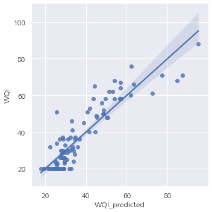

```python
sns.lmplot(x = 'WQI_predicted', y = 'WQI', data = water)
```

예측결과 = 관측값과 예측값이 일치하는 경향을 보이므로 예측을 잘 한다고 볼 수 있다.

# Q . 수질예측 및 순위예측

```python
lm_water_1.params
```

```
Intercept    98.440209
LDO          -0.595539
salt         -0.345515
SD           -2.103014
DIP           0.091775
Chl_a         0.836542
dtype: float64
```

```python
LDO_t = float(input('LDO(43~124) :'))
salt_t = float(input('salt(34.3~35) :'))
SD_t = float(input('SD(0.4~6) :'))
DIP_t = float(input('DIP(4.6~327.3) :'))
Chl_a_t = float(input('Chl_a(0.000e+00~4.151e+01) :'))
```

```
LDO(43~124) :46
salt(34.3~35) :34.6
SD(0.4~6) :3
DIP(4.6~327.3) :200
Chl_a(0.000e+00~4.151e+01) :4.151
```

```python
t = 98.440209 -0.595539*LDO_t -0.345515 *salt_t -2.103014 * SD_t +0.091775*DIP_t + 0.836542*Chl_a_t
t
```

```
74.609
```

```python
m =water['WQI'].mean()
s = water['WQI'].std(ddof = 1)
print(m,s)
```

```
37.11 17.1857910536994
```

```python
p = stats.norm.cdf (loc = 37.11,scale=17.1857910536994,x = t)
p
```

```
0.9854444687003424
```

```python
k = water['WQI'].unique()
k.sort()
k
```

```
array([20, 22, 23, 24, 25, 26, 28, 29, 30, 31, 32, 33, 34, 36, 37, 40, 41,
       45, 46, 48, 49, 50, 51, 52, 53, 56, 58, 60, 61, 62, 64, 65, 66, 67,
       68, 71, 76, 88], dtype=int64)
```

# B. 수질의 좋음 or 나쁨 예측 ( Logistic )

일반선형모델 = 정규분포 이외의 확률분포를 사용할 수 있다.

로지스틱 회귀 = 확률분포에 이항분포를 사용하고, 링크함수에 로짓함수를 사용한 일반선형모델

독립변수는 여러 개 있어도 상관없고, 연속형과 카테고리형이 섞여있어도 상관없다

=> 즉, 더 일반적인 회귀분석을 할 때 사용한다.

원래 수질 등급은 총 5가지 등급인데 좋음과 나쁨 두 가지로 분류를 해서 로지스틱 회귀분석을 한다.

# 1. classification

```python
Rank = water['rank']
# 좋음 나쁨으로 수질 분류
water['NWQ'] = [1 if p == 'I' or p == 'II' else 0 for p in Rank]
water.head()
```

| 2020년 분기 | 조사정점 | pH | total coliform group | WQI | rank | DIN | DIP | Chl_a | LDO | SD | ... | Ni | COD | T-N | T-P | DO | temperature | electrical_conductivity | salt | WQI_predicted | NWQ |
| --- | --- | --- | --- | --- | --- | --- | --- | --- | --- | --- | --- | --- | --- | --- | --- | --- | --- | --- | --- | --- | --- |
| 1 | 고리 | 7.72 | 23 | 20 | I | 94.0 | 6.8 | 0.57 | 96.9 | 2.5 | ... | 0.78 | 1.32 | 203.5 | 7.9 | 8.18 | 14.11 | 50.9 | 33.40 | 25.035640 | 1 |
| 1 | 일광 | 8.05 | 2 | 26 | II | 99.0 | 18.2 | 0.38 | 94.9 | 2.0 | ... | 0.23 | 0.80 | 255.9 | 23.7 | 8.07 | 13.66 | 50.8 | 33.31 | 28.196609 | 1 |
| 1 | 대변 | 8.12 | 2 | 26 | II | 111.4 | 10.5 | 0.09 | 94.5 | 2.0 | ... | 0.22 | 0.92 | 234.9 | 17.8 | 8.06 | 13.46 | 50.8 | 33.34 | 27.475198 | 1 |
| 1 | 해운대해수욕장 | 8.00 | 330 | 23 | I | 132.5 | 14.4 | 0.34 | 96.8 | 2.3 | ... | 0.18 | 0.88 | 259.8 | 18.5 | 8.05 | 13.75 | 50.9 | 33.41 | 26.017424 | 1 |
| 1 | 해운대 | 8.02 | 170 | 20 | I | 184.7 | 21.8 | 0.34 | 96.7 | 2.5 | ... | 0.43 | 0.92 | 385.7 | 24.8 | 7.99 | 13.72 | 50.5 | 33.10 | 26.442617 | 1 |

5 rows × 25 columns

```python
print(water[water['NWQ'] == 1]['조사정점'].count())
print(water[water['NWQ'] == 0]['조사정점'].count())
```

```
55
45
```

# 2. Model

```python
mod_glm_LDO = smf.glm(formula = "NWQ ~ LDO", data = water,
                  family = sm.families.Binomial()).fit()
mod_glm_salt = smf.glm(formula = "NWQ ~ salt", data = water,
                  family = sm.families.Binomial()).fit()
mod_glm_SD = smf.glm(formula = "NWQ ~ SD", data = water,
                  family = sm.families.Binomial()).fit()
mod_glm_DIP = smf.glm(formula = "NWQ ~ DIP", data = water,
                  family = sm.families.Binomial()).fit()
mod_glm_Chl_a = smf.glm(formula = "NWQ ~ Chl_a", data = water,
                  family = sm.families.Binomial()).fit()
```

```python
print("LDO　：", mod_glm_LDO.aic.round(3))
print("salt：", mod_glm_salt.aic.round(3))
print("SD：", mod_glm_SD.aic.round(3))
print("DIP：", mod_glm_DIP.aic.round(3))
print("Chl_a：", mod_glm_Chl_a.aic.round(3))
```

```
LDO　： 110.665
salt： 85.556
SD： 127.346
DIP： 112.197
Chl_a： 113.854
```

여러 개의 요인(독립변수)를 이용해 수질을 가장 잘 예측하는 로지스틱 회귀 모델

```python
mod_glm_1 = smf.glm(formula = "NWQ ~ SD", data = water,
                  family = sm.families.Binomial()).fit()
mod_glm_2 = smf.glm(formula = "NWQ ~ SD + Chl_a", data = water,
                  family = sm.families.Binomial()).fit()
mod_glm_3 = smf.glm(formula = "NWQ ~ SD + Chl_a + DIP ", data = water,
                  family = sm.families.Binomial()).fit()
mod_glm_4 = smf.glm(formula = "NWQ ~ SD + Chl_a + DIP + LDO", data = water,
                  family = sm.families.Binomial()).fit()
mod_glm_5 = smf.glm(formula = "NWQ ~ SD + Chl_a + DIP + LDO + salt", data = water,
                  family = sm.families.Binomial()).fit()
```

### aic값으로 예측을 가장 잘 하는 모델 정하기

```python
print(mod_glm_1.aic)
print(mod_glm_2.aic)
print(mod_glm_3.aic)
print(mod_glm_4.aic)
print(mod_glm_5.aic) # 가장 예측을 잘 하는 모델
```

```
127.34605533829857
106.2189339661347
70.20336726906538
58.643355854152965
45.22143164107734
```

### 독립변수의 각 계수가 유의한지 보기

```python
mod_glm_1.summary().tables[1]
```

|  | coef | std err | z | P>\|z\| | [0.025 | 0.975] |
| --- | --- | --- | --- | --- | --- | --- |
| Intercept | -1.6185 | 0.564 | -2.871 | 0.004 | -2.723 | -0.514 |
| SD | 0.6685 | 0.197 | 3.391 | 0.001 | 0.282 | 1.055 |

```python
mod_glm_2.summary().tables[1] #intercept가 유의하지 않음
```

|  | coef | std err | z | P>\|z\| | [0.025 | 0.975] |
| --- | --- | --- | --- | --- | --- | --- |
| Intercept | -0.4462 | 0.629 | -0.709 | 0.478 | -1.680 | 0.787 |
| SD | 0.5929 | 0.209 | 2.835 | 0.005 | 0.183 | 1.003 |
| Chl_a | -0.2297 | 0.066 | -3.455 | 0.001 | -0.360 | -0.099 |

```python
mod_glm_3.summary().tables[1]
```

|  | coef | std err | z | P>\|z\| | [0.025 | 0.975] |
| --- | --- | --- | --- | --- | --- | --- |
| Intercept | 3.3004 | 1.209 | 2.729 | 0.006 | 0.930 | 5.670 |
| SD | 0.3486 | 0.288 | 1.209 | 0.227 | -0.217 | 0.914 |
| Chl_a | -0.3254 | 0.084 | -3.872 | 0.000 | -0.490 | -0.161 |
| DIP | -0.0767 | 0.018 | -4.176 | 0.000 | -0.113 | -0.041 |

```python
mod_glm_4.summary().tables[1]
```

|  | coef | std err | z | P>\|z\| | [0.025 | 0.975] |
| --- | --- | --- | --- | --- | --- | --- |
| Intercept | -8.9563 | 4.294 | -2.086 | 0.037 | -17.373 | -0.540 |
| SD | 0.3086 | 0.335 | 0.922 | 0.357 | -0.348 | 0.965 |
| Chl_a | -0.3686 | 0.106 | -3.475 | 0.001 | -0.577 | -0.161 |
| DIP | -0.0728 | 0.019 | -3.821 | 0.000 | -0.110 | -0.035 |
| LDO | 0.1358 | 0.047 | 2.892 | 0.004 | 0.044 | 0.228 |

```python
mod_glm_5.summary().tables[1] #SD의 계수가 유의하지 않음
```

|  | coef | std err | z | P>\|z\| | [0.025 | 0.975] |
| --- | --- | --- | --- | --- | --- | --- |
| Intercept | -61.3536 | 23.283 | -2.635 | 0.008 | -106.987 | -15.721 |
| SD | -0.0050 | 0.368 | -0.014 | 0.989 | -0.727 | 0.717 |
| Chl_a | -0.4516 | 0.173 | -2.611 | 0.009 | -0.790 | -0.113 |
| DIP | -0.0729 | 0.023 | -3.128 | 0.002 | -0.119 | -0.027 |
| LDO | 0.1865 | 0.074 | 2.532 | 0.011 | 0.042 | 0.331 |
| salt | 1.4911 | 0.608 | 2.453 | 0.014 | 0.300 | 2.683 |

#### 최종 로지스틱 회귀모델

```python
glm_water =smf.glm(formula = "NWQ ~ SD + Chl_a + DIP + LDO + salt", data = water,
                  family = sm.families.Binomial()).fit()
```

```python
glm_water.params
```

```
Intercept   -61.353645
SD           -0.005026
Chl_a        -0.451573
DIP          -0.072903
LDO           0.186480
salt          1.491139
dtype: float64
```

```python
glm_water.summary()
```

Generalized Linear Model Regression Results

| Dep. Variable: | NWQ | No. Observations: | 100 |
| --- | --- | --- | --- |
| Model: | GLM | Df Residuals: | 94 |
| Model Family: | Binomial | Df Model: | 5 |
| Link Function: | logit | Scale: | 1.0000 |
| Method: | IRLS | Log-Likelihood: | -16.611 |
| Date: | Mon, 07 Jun 2021 | Deviance: | 33.221 |
| Time: | 20:31:11 | Pearson chi2: | 32.4 |
| No. Iterations: | 10 |  |  |
| Covariance Type: | nonrobust |  |  |

|  | coef | std err | z | P>\|z\| | [0.025 | 0.975] |
| --- | --- | --- | --- | --- | --- | --- |
| Intercept | -61.3536 | 23.283 | -2.635 | 0.008 | -106.987 | -15.721 |
| SD | -0.0050 | 0.368 | -0.014 | 0.989 | -0.727 | 0.717 |
| Chl_a | -0.4516 | 0.173 | -2.611 | 0.009 | -0.790 | -0.113 |
| DIP | -0.0729 | 0.023 | -3.128 | 0.002 | -0.119 | -0.027 |
| LDO | 0.1865 | 0.074 | 2.532 | 0.011 | 0.042 | 0.331 |
| salt | 1.4911 | 0.608 | 2.453 | 0.014 | 0.300 | 2.683 |

# 3. Prediction

```python
predict_1 = glm_water.predict()
water ['NWQ_predicted'] = predict_1
water.head()
```

| 2020년 분기 | 조사정점 | pH | total coliform group | WQI | rank | DIN | DIP | Chl_a | LDO | SD | ... | COD | T-N | T-P | DO | temperature | electrical_conductivity | salt | WQI_predicted | NWQ | NWQ_predicted |
| --- | --- | --- | --- | --- | --- | --- | --- | --- | --- | --- | --- | --- | --- | --- | --- | --- | --- | --- | --- | --- | --- |
| 1 | 고리 | 7.72 | 23 | 20 | I | 94.0 | 6.8 | 0.57 | 96.9 | 2.5 | ... | 1.32 | 203.5 | 7.9 | 8.18 | 14.11 | 50.9 | 33.40 | 25.035640 | 1 | 0.996842 |
| 1 | 일광 | 8.05 | 2 | 26 | II | 99.0 | 18.2 | 0.38 | 94.9 | 2.0 | ... | 0.80 | 255.9 | 23.7 | 8.07 | 13.66 | 50.8 | 33.31 | 28.196609 | 1 | 0.989064 |
| 1 | 대변 | 8.12 | 2 | 26 | II | 111.4 | 10.5 | 0.09 | 94.5 | 2.0 | ... | 0.92 | 234.9 | 17.8 | 8.06 | 13.46 | 50.8 | 33.34 | 27.475198 | 1 | 0.994331 |
| 1 | 해운대해수욕장 | 8.00 | 330 | 23 | I | 132.5 | 14.4 | 0.34 | 96.8 | 2.3 | ... | 0.88 | 259.8 | 18.5 | 8.05 | 13.75 | 50.9 | 33.41 | 26.017424 | 1 | 0.995042 |
| 1 | 해운대 | 8.02 | 170 | 20 | I | 184.7 | 21.8 | 0.34 | 96.7 | 2.5 | ... | 0.92 | 385.7 | 24.8 | 7.99 | 13.72 | 50.5 | 33.10 | 26.442617 | 1 | 0.986350 |

5 rows × 26 columns

### 예측률

```python
#예측률

water['NWQ_predicted2'] = [1.0 if x >= 0.5 else 0.0 for x in predict_1]



(len(water)-len(water[water['NWQ'] != water['NWQ_predicted2']]))/len(water)
```

```
0.890
```

## 4. Rank by prediction

```python
water['rank_by_quarter'] = water.groupby('2020년 분기')['NWQ_predicted'].rank(ascending = False)
```

```python
#분기 나누기
water_1 = water.loc[1]
water_2 = water.loc[2]
water_3 = water.loc[3]
water_4 = water.loc[4]
```

```
([0,
  1,
  2,
  3,
  4,
  5,
  6,
  7,
  8,
  9,
  10,
  11,
  12,
  13,
  14,
  15,
  16,
  17,
  18,
  19,
  20,
  21,
  22,
  23,
  24,
  25,
  26,
  27,
  28,
  29],
 <a list of 30 Text xticklabel objects>)
```

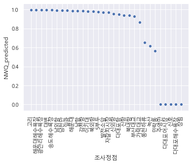

```python
water_1 = water_1.sort_values(by = 'rank_by_quarter')
wg_Q1 = sns.scatterplot('조사정점','NWQ_predicted',data = water_1)
plt.xticks (rotation = 90)
```

```
([0, 1, 2, 3, 4, 5, 6, 7, 8, 9, 10, 11, 12, 13, 14, 15, 16, 17, 18, 19],
 <a list of 20 Text xticklabel objects>)
```

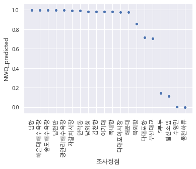

```python
water_2 = water_2.sort_values(by = 'rank_by_quarter')
wg_Q2 = sns.scatterplot('조사정점','NWQ_predicted',data = water_2)
plt.xticks (rotation = 90)
```

```
([0,
  1,
  2,
  3,
  4,
  5,
  6,
  7,
  8,
  9,
  10,
  11,
  12,
  13,
  14,
  15,
  16,
  17,
  18,
  19,
  20,
  21,
  22,
  23,
  24,
  25,
  26,
  27,
  28,
  29],
 <a list of 30 Text xticklabel objects>)
```

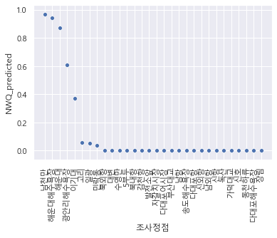

```python
water_3 = water_3.sort_values(by = 'rank_by_quarter')
wg_Q3 = sns.scatterplot('조사정점','NWQ_predicted',data = water_3)
plt.xticks (rotation = 90)
```

```
([0, 1, 2, 3, 4, 5, 6, 7, 8, 9, 10, 11, 12, 13, 14, 15, 16, 17, 18, 19],
 <a list of 20 Text xticklabel objects>)
```

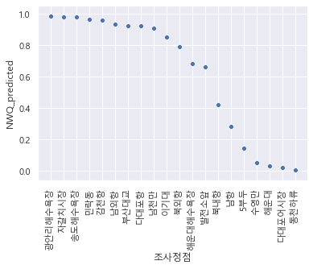

```python
water_4 = water_4.sort_values(by = 'rank_by_quarter')
wg_Q4 = sns.scatterplot('조사정점','NWQ_predicted',data = water_4)
plt.xticks (rotation = 90)
```

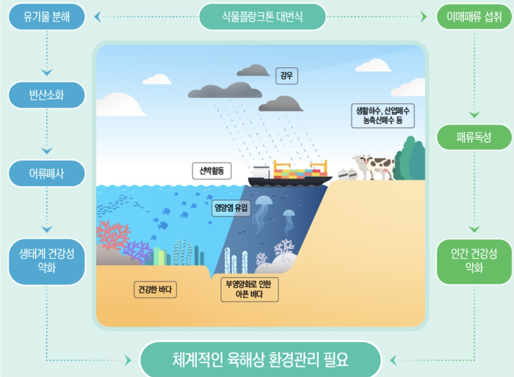

```python
Image('그림 2.jpg')
```